# Pandas

# FFP to school enrollment

The ration of FPP to school enrollment - similar to total people on trip. Could be significant

```
count    3095.000000
mean        0.055633
std         0.060728
min         0.000000
25%         0.016250
50%         0.036423
75%         0.068906
max         0.500594
Name: FPP_to_School_enrollment, dtype: float64
```

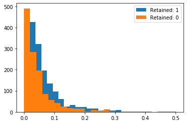

```python
print(clean_data['FPP_to_School_enrollment'].describe())


pyplot.hist(clean_data.loc[clean_data['Retained'] == 1, 'FPP_to_School_enrollment'], bins = 25, label = 'Retained: 1')
pyplot.hist(clean_data.loc[clean_data['Retained'] == 0, 'FPP_to_School_enrollment'], bins = 25, label = 'Retained: 0')
pyplot.legend(loc='upper right')
pyplot.show()
```

# Poverty code

Poverty code for the school based on estimated percentage below the powerty line. A 0-5.9, B 6-15,9, C 16-30.9, D 31 or more, E unclassified, Space if distclass = U

```
B    1656
C     881
A     462
D      67
E      29
Name: Poverty_Code, dtype: int64
```

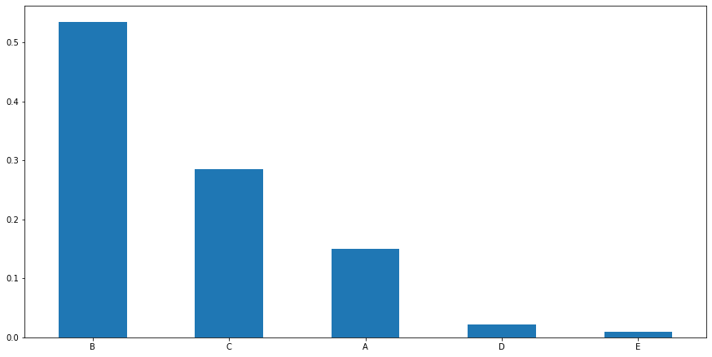

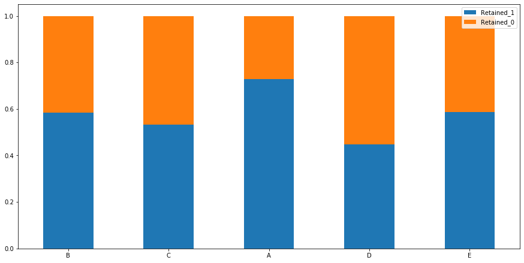

```python
cat_variable_plot('Poverty_Code', clean_data)
```

# Region

State areas

```
Other                  1607
Southern California     459
Northern California     316
Pacific Northwest       269
Dallas                  256
Houston                 188
Name: Region, dtype: int64
```

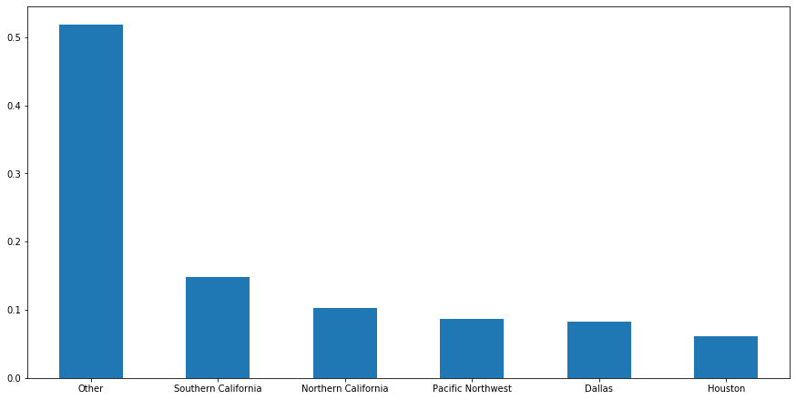

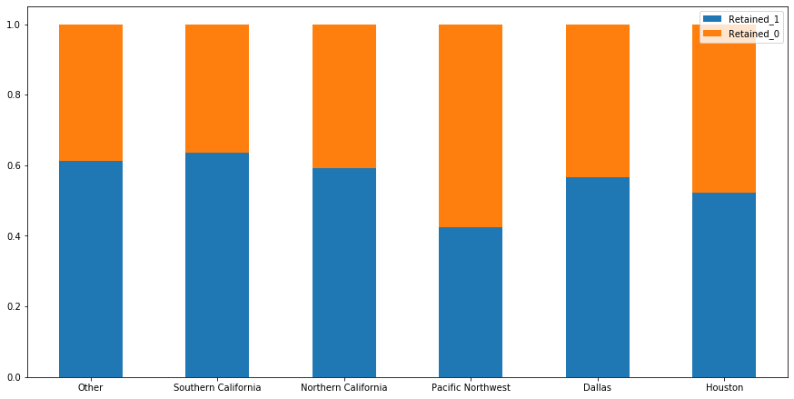

```python
cat_variable_plot('Region', clean_data)
```

# School type

Public or private

```
PUBLIC    3078
CHD         17
Name: School_Type, dtype: int64
```

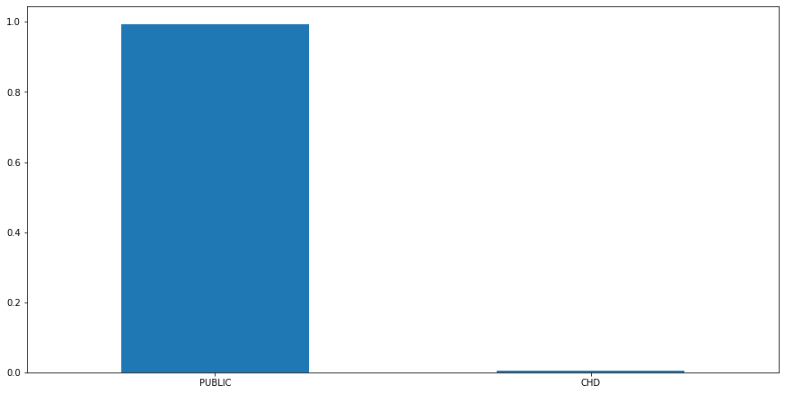

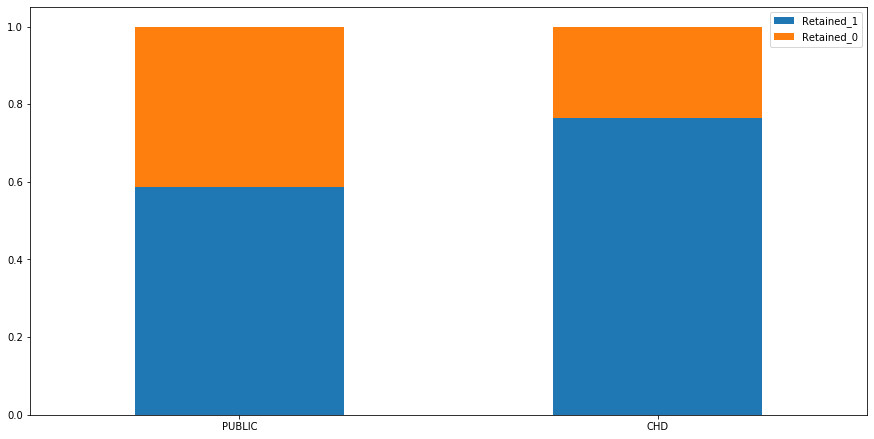

```python
cat_variable_plot('School_Type', clean_data)
```

# Parent meeting flag

Indication wether a parent meeting was held

```
1    2743
0     352
Name: Parent_Meeting_Flag, dtype: int64
```

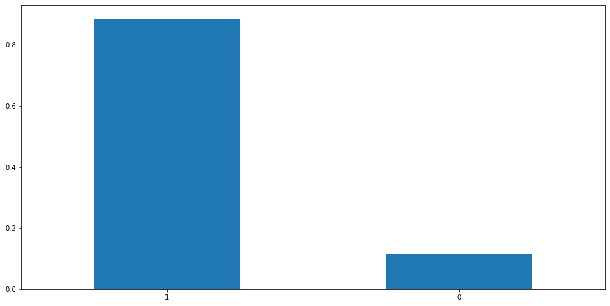

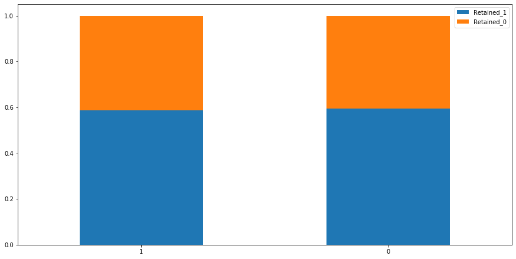

```python
cat_variable_plot('Parent_Meeting_Flag', clean_data)
```

# MDR Low grade

Lowest grade in the school

```
6     1486
7      571
K      459
PK     166
9      165
5      163
4       25
8       23
3       21
1        7
10       5
2        4
Name: MDR_Low_Grade, dtype: int64
```

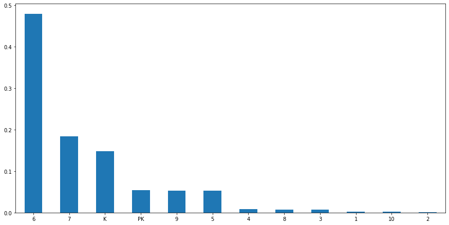

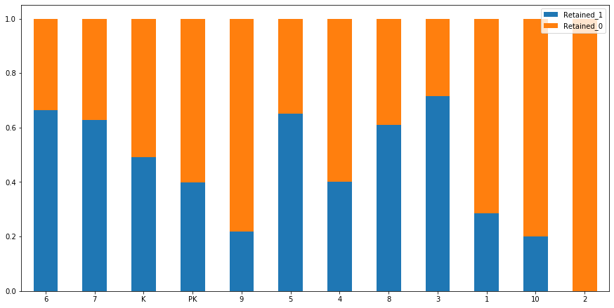

```python
cat_variable_plot('MDR_Low_Grade', clean_data)
```

# MDR Hight grade

Highest grade in the school

```
8.0     2300
12.0     362
5.0      164
6.0      133
9.0       86
7.0       36
1.0        4
4.0        3
10.0       3
3.0        2
11.0       2
Name: MDR_High_Grade, dtype: int64
```

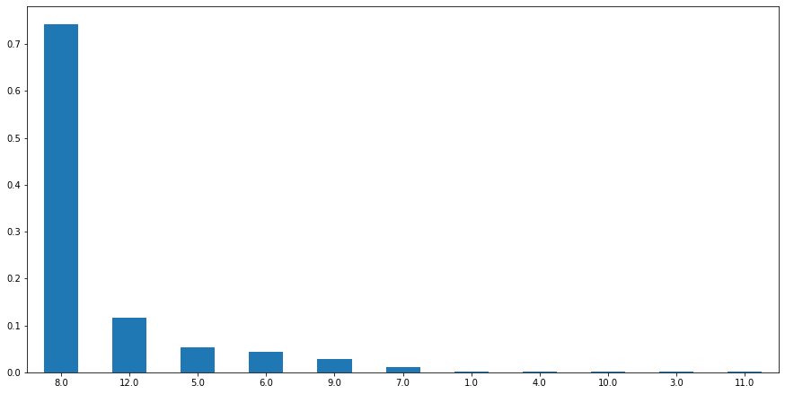

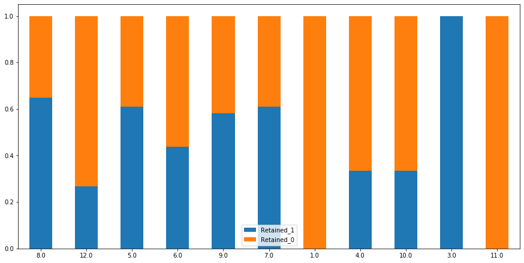

```python
cat_variable_plot('MDR_High_Grade', clean_data)
```

# Total school enrollment

School enrolments

```
count    3095.000000
mean      711.264943
std       419.442991
min         0.000000
25%       444.000000
50%       656.000000
75%       890.000000
max      4005.000000
Name: Total_School_Enrollment, dtype: float64
```

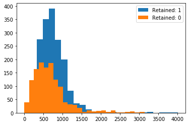

```python
print(clean_data['Total_School_Enrollment'].describe())


pyplot.hist(clean_data.loc[clean_data['Retained'] == 1, 'Total_School_Enrollment'], bins = 25, label = 'Retained: 1')
pyplot.hist(clean_data.loc[clean_data['Retained'] == 0, 'Total_School_Enrollment'], bins = 25, label = 'Retained: 0')
pyplot.legend(loc='upper right')
pyplot.show()
```

# Income level

Parent income level. A is lowest, Q is highest, Z is unclassified

```
O     352
Q     336
L     280
M     255
P     239
N     224
I     223
J     206
K     177
F     147
G     129
E     122
H     119
C      98
D      57
Z      52
B      50
A      20
P4      4
P3      3
P1      2
Name: Income_Level, dtype: int64
```

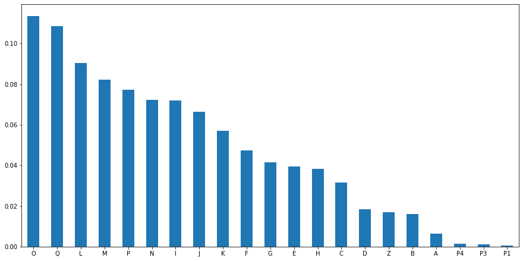

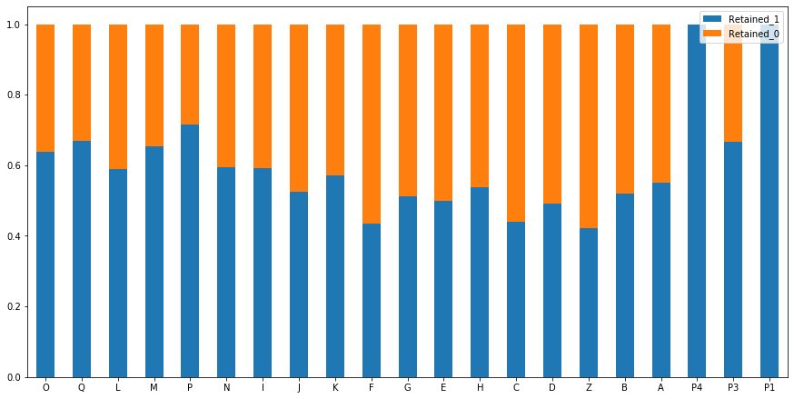

```python
cat_variable_plot('Income_Level', clean_data)
```

# SPR new existing

New client indicator

```
1    1564
0    1531
Name: SPR_New_Existing, dtype: int64
```

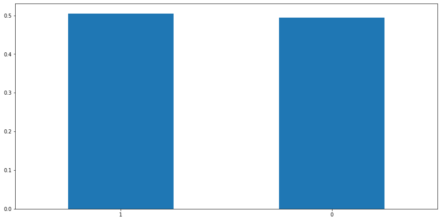

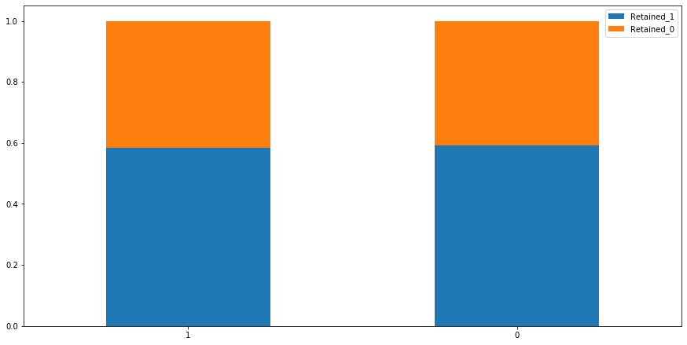

```python
cat_variable_plot('SPR_New_Existing', clean_data)
```

# Number of meetings with parents

Number of meetings with parents prior to the trip

```
1    1929
2     814
0     352
Name: NumberOfMeetingswithParents, dtype: int64
```

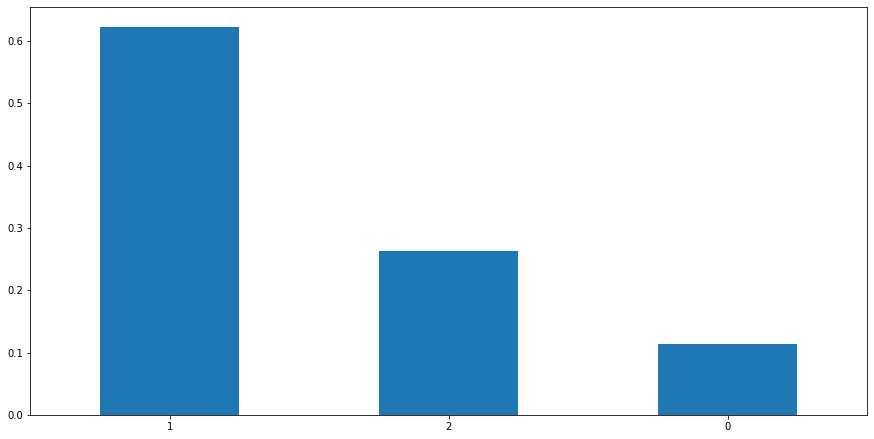

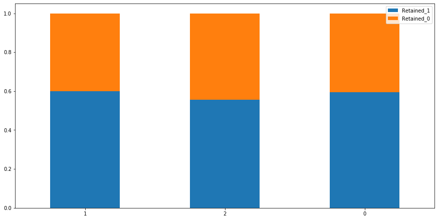

```python
cat_variable_plot('NumberOfMeetingswithParents', clean_data)
```

# Difference travel to first meeting, Difference travel to last meeting

Days from the first/last parent meeting to travel date

```
count    3095.000000
mean      263.859774
std        76.329012
min      -209.000000
25%       218.000000
50%       254.000000
75%       283.000000
max       752.000000
Name: DifferenceTraveltoFirstMeeting, dtype: float64
```

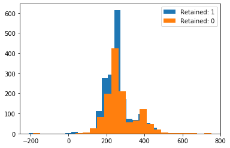

```python
print(clean_data['DifferenceTraveltoFirstMeeting'].describe())


pyplot.hist(clean_data.loc[clean_data['Retained'] == 1, 'DifferenceTraveltoFirstMeeting'], bins = 25, label = 'Retained: 1')
pyplot.hist(clean_data.loc[clean_data['Retained'] == 0, 'DifferenceTraveltoFirstMeeting'], bins = 25, label = 'Retained: 0')
pyplot.legend(loc='upper right')
pyplot.show()
```

```
count    3095.000000
mean      231.081422
std        51.801407
min      -208.000000
25%       202.000000
50%       236.000000
75%       261.000000
max       759.000000
Name: DifferenceTraveltoLastMeeting, dtype: float64
```

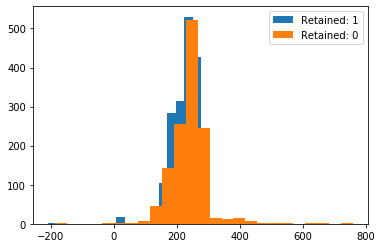

```python
print(clean_data['DifferenceTraveltoLastMeeting'].describe())


pyplot.hist(clean_data.loc[clean_data['Retained'] == 1, 'DifferenceTraveltoLastMeeting'], bins = 25, label = 'Retained: 1')
pyplot.hist(clean_data.loc[clean_data['Retained'] == 0, 'DifferenceTraveltoLastMeeting'], bins = 25, label = 'Retained: 0')
pyplot.legend(loc='upper right')
pyplot.show()
```

# Shool Grade type low

The lowest grade type in school- maybe we can check if the values correspond to MDR_Low_grade

```
Middle        2482
Elementary     267
High           185
Undefined      161
Name: SchoolGradeTypeLow, dtype: int64
```

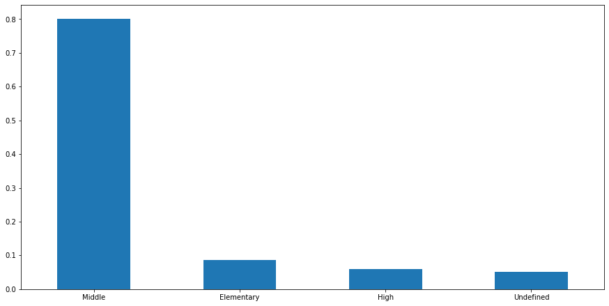

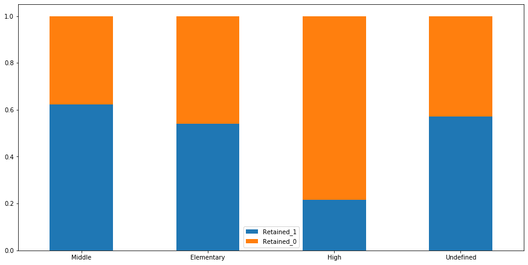

```python
cat_variable_plot('SchoolGradeTypeLow', clean_data)
```

# School grade type high

The highest grade type in school

```
Middle        2340
High           366
Undefined      195
Elementary     194
Name: SchoolGradeTypeHigh, dtype: int64
```

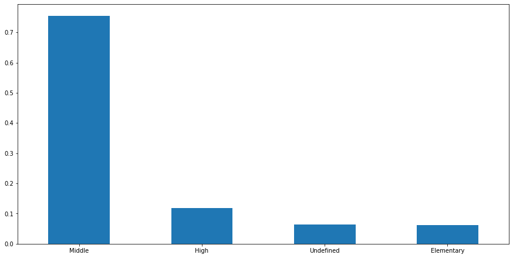

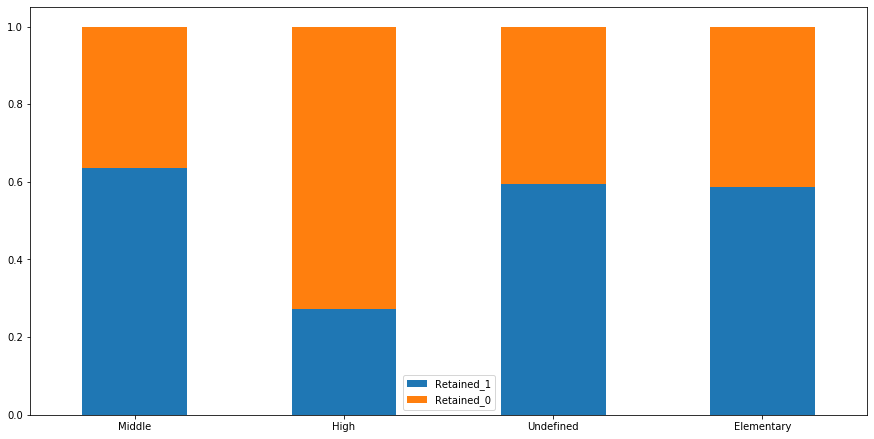

```python
cat_variable_plot('SchoolGradeTypeHigh', clean_data)
```

# School grade type

Combination of school grade type low and school grade type high

```
Middle->Middle            2273
Elementary->Elementary     194
High->High                 185
Middle->High               177
Undefined->Undefined       161
Elementary->Middle          67
Middle->Undefined           32
Elementary->High             4
Elementary->Undefined        2
Name: SchoolGradeType, dtype: int64
```

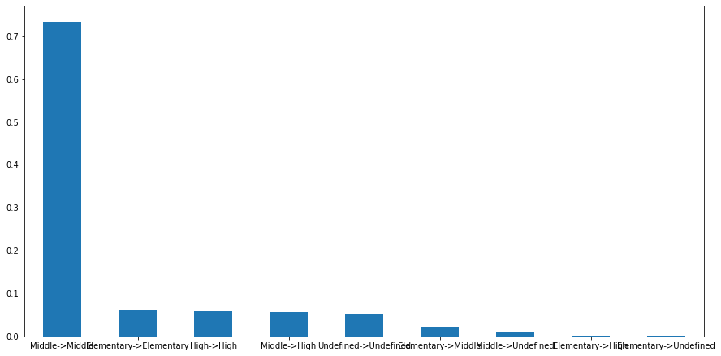

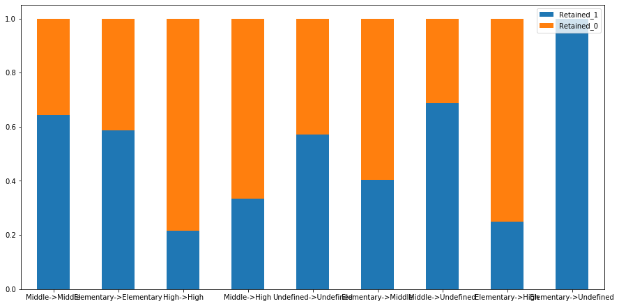

```python
cat_variable_plot('SchoolGradeType', clean_data)
```

# School size indicator

Size of school

```
L      976
M-L    895
S-M    797
S      427
Name: SchoolSizeIndicator, dtype: int64
```

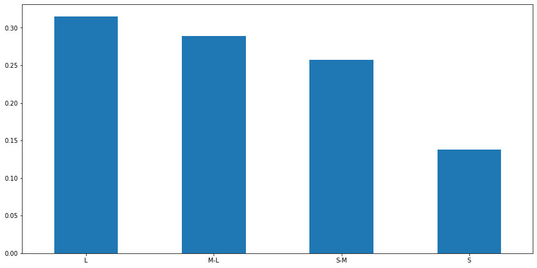

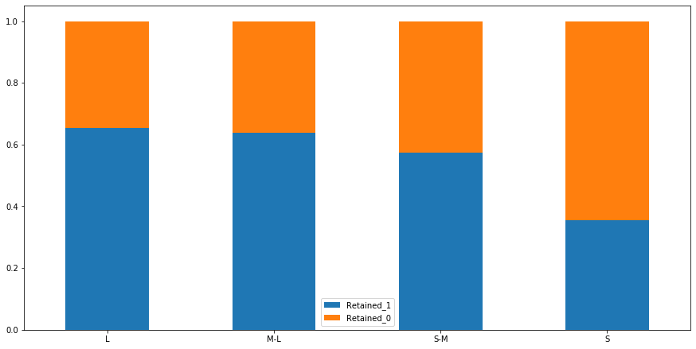

```python
cat_variable_plot('SchoolSizeIndicator', clean_data)
```

# Tuition

price per full-payment participant (FPP)

```
count    3095.000000
mean     1623.100162
std       634.739373
min        72.000000
25%      1201.500000
50%      1711.000000
75%      2048.000000
max      4164.000000
Name: Tuition, dtype: float64
```

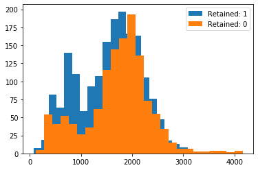

```python
print(clean_data['Tuition'].describe())


pyplot.hist(clean_data.loc[clean_data['Retained'] == 1, 'Tuition'], bins = 25, label = 'Retained: 1')
pyplot.hist(clean_data.loc[clean_data['Retained'] == 0, 'Tuition'], bins = 25, label = 'Retained: 0')
pyplot.legend(loc='upper right')
pyplot.show()
```

# FRP Active

Number of FPP's who bought trip cancelation insurance

```
count    3095.000000
mean       17.145396
std        18.010022
min         0.000000
25%         6.000000
50%        12.000000
75%        22.000000
max       269.000000
Name: FRP_Active, dtype: float64
```

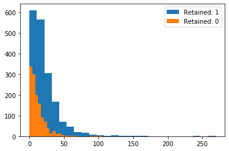

```python
print(clean_data['FRP_Active'].describe())


pyplot.hist(clean_data.loc[clean_data['Retained'] == 1, 'FRP_Active'], bins = 25, label = 'Retained: 1')
pyplot.hist(clean_data.loc[clean_data['Retained'] == 0, 'FRP_Active'], bins = 25, label = 'Retained: 0')
pyplot.legend(loc='upper right')
pyplot.show()
```

# FRP Cancelled

Number of FPPs who bought trip cancellation insurance and cancellerd

```
count    3095.000000
mean        3.684653
std         3.863049
min         0.000000
25%         1.000000
50%         3.000000
75%         5.000000
max        45.000000
Name: FRP_Cancelled, dtype: float64
```

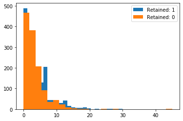

```python
print(clean_data['FRP_Cancelled'].describe())


pyplot.hist(clean_data.loc[clean_data['Retained'] == 1, 'FRP_Cancelled'], bins = 25, label = 'Retained: 1')
pyplot.hist(clean_data.loc[clean_data['Retained'] == 0, 'FRP_Cancelled'], bins = 25, label = 'Retained: 0')
pyplot.legend(loc='upper right')
pyplot.show()
```

# FRP Take up Percent

Percentage of FPP's who bought the insurance pay for it

```
count    3095.000000
mean        0.587370
std         0.213590
min         0.000000
25%         0.476216
50%         0.605563
75%         0.729379
max         1.049834
Name: FRP_Take_up_percent_, dtype: float64
```

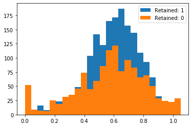

```python
print(clean_data['FRP_Take_up_percent_'].describe())


pyplot.hist(clean_data.loc[clean_data['Retained'] == 1, 'FRP_Take_up_percent_'], bins = 25, label = 'Retained: 1')
pyplot.hist(clean_data.loc[clean_data['Retained'] == 0, 'FRP_Take_up_percent_'], bins = 25, label = 'Retained: 0')
pyplot.legend(loc='upper right')
pyplot.show()
```

# EZ pay take up rate

Percentage of FPPs use automatic bank draft

```
count    3095.000000
mean        0.219015
std         0.162009
min         0.000000
25%         0.110302
50%         0.201111
75%         0.303660
max         1.970037
Name: EZ_Pay_Take_Up_Rate, dtype: float64
```

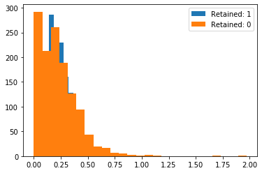

```python
print(clean_data['EZ_Pay_Take_Up_Rate'].describe())


pyplot.hist(clean_data.loc[clean_data['Retained'] == 1, 'EZ_Pay_Take_Up_Rate'], bins = 25, label = 'Retained: 1')
pyplot.hist(clean_data.loc[clean_data['Retained'] == 0, 'EZ_Pay_Take_Up_Rate'], bins = 25, label = 'Retained: 0')
pyplot.legend(loc='upper right')
pyplot.show()
```

# School Sponsor

Indication of whether or not the school is sponsoring the trip

```
0    2944
1     151
Name: School_Sponsor, dtype: int64
```

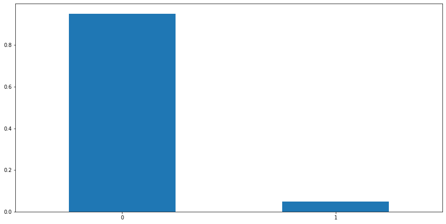

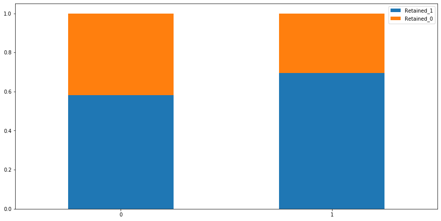

```python
cat_variable_plot('School_Sponsor', clean_data)
```

# SPR_Group_revenue

Amount paid for all of the participants

```
count    3095.000000
mean     1618.927625
std       629.412721
min        73.000000
25%      1195.000000
50%      1707.000000
75%      2050.000000
max      4255.000000
Name: SPR_Group_Revenue, dtype: float64
```

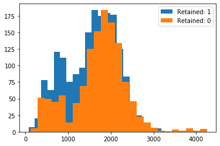

```python
print(clean_data['SPR_Group_Revenue'].describe())


pyplot.hist(clean_data.loc[clean_data['Retained'] == 1, 'SPR_Group_Revenue'], bins = 25, label = 'Retained: 1')
pyplot.hist(clean_data.loc[clean_data['Retained'] == 0, 'SPR_Group_Revenue'], bins = 25, label = 'Retained: 0')
pyplot.legend(loc='upper right')
pyplot.show()
```

# FPP to PAX

Percentage of FPP

```
count    3095.000000
mean        0.895238
std         0.056860
min         0.593169
25%         0.867926
50%         0.902647
75%         0.932423
max         1.048725
Name: FPP_to_PAX, dtype: float64
```

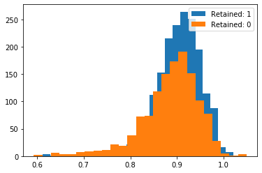

```python
print(clean_data['FPP_to_PAX'].describe())


pyplot.hist(clean_data.loc[clean_data['Retained'] == 1, 'FPP_to_PAX'], bins = 25, label = 'Retained: 1')
pyplot.hist(clean_data.loc[clean_data['Retained'] == 0, 'FPP_to_PAX'], bins = 25, label = 'Retained: 0')
pyplot.legend(loc='upper right')
pyplot.show()
```

# Num of Non FPP_PAX

NUmber of non-FPP participants

```
count    3095.000000
mean        3.041034
std         3.196930
min         0.000000
25%         1.000000
50%         2.000000
75%         4.000000
max        50.000000
Name: Num_of_Non_FPP_PAX, dtype: float64
```

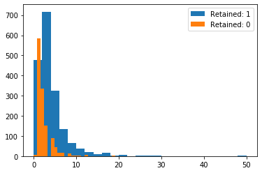

```python
print(clean_data['Num_of_Non_FPP_PAX'].describe())


pyplot.hist(clean_data.loc[clean_data['Retained'] == 1, 'Num_of_Non_FPP_PAX'], bins = 25, label = 'Retained: 1')
pyplot.hist(clean_data.loc[clean_data['Retained'] == 0, 'Num_of_Non_FPP_PAX'], bins = 25, label = 'Retained: 0')
pyplot.legend(loc='upper right')
pyplot.show()
```

# Correlation matrix between numerical features

```python
import seaborn as sn
```

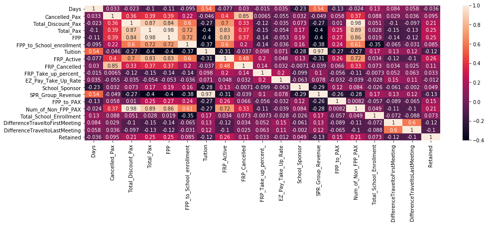

```python
corr_data = clean_data[[
'Days'
,'Cancelled_Pax'
,'Total_Discount_Pax'
,'Total_Pax'
,'FPP'
,'FPP_to_School_enrollment'
,'Tuition'
,'FRP_Active'
,'FRP_Cancelled'
,'FRP_Take_up_percent_'
,'EZ_Pay_Take_Up_Rate'
,'School_Sponsor'
,'SPR_Group_Revenue'
,'FPP_to_PAX'
,'Num_of_Non_FPP_PAX'
,'Total_School_Enrollment'
,'DifferenceTraveltoFirstMeeting'
,'DifferenceTraveltoLastMeeting'
,'Retained'
]]

corrMatrix = corr_data.corr()
pyplot.figure(figsize = (16,5))
sn.heatmap(corrMatrix, annot=True)
pyplot.show()
```

https://towardsdatascience.com/the-search-for-categorical-correlation-a1cf7f1888c9 http://shakedzy.xyz/dython/modules/nominal/

Could be interesting

```python
pip install dython
```

```python
from dython.nominal import associations
from dython.nominal import identify_numeric_columns
```

```python
identify_numeric_columns(clean_data)
```

```
['Unnamed: 0',
 'From_Grade',
 'To_Grade',
 'Days',
 'Cancelled_Pax',
 'Total_Discount_Pax',
 'FPP',
 'Total_Pax',
 'FPP_to_School_enrollment',
 'Retained',
 'ID',
 'Tuition',
 'FRP_Active',
 'FRP_Cancelled',
 'FRP_Take_up_percent_',
 'EZ_Pay_Take_Up_Rate',
 'School_Sponsor',
 'SPR_Group_Revenue',
 'FPP_to_PAX',
 'Num_of_Non_FPP_PAX',
 'CRM_Segment',
 'Parent_Meeting_Flag',
 'MDR_High_Grade',
 'Total_School_Enrollment',
 'SPR_New_Existing',
 'NumberOfMeetingswithParents',
 'DifferenceTraveltoFirstMeeting',
 'DifferenceTraveltoLastMeeting']
```

```python
clean_data1 = clean_data[[ 'Program_Code'
,'From_Grade'
,'To_Grade'
,'Group_State'
,'Days'
,'Travel_Type'
,'Cancelled_Pax'
,'Total_Discount_Pax'
,'SPR_Product_Type'
,'FPP'
,'Total_Pax'
,'DepartureMonth'
,'GroupGradeTypeLow'
,'GroupGradeTypeHigh'
,'GroupGradeType'
,'MajorProgramCode'
,'FPP_to_School_enrollment'
,'Tuition'
,'FRP_Active'
,'FRP_Cancelled'
,'FRP_Take_up_percent_'
,'EZ_Pay_Take_Up_Rate'
,'School_Sponsor'
,'SPR_Group_Revenue'
,'FPP_to_PAX'
,'Num_of_Non_FPP_PAX'
,'Poverty_Code'
,'Region'
,'School_Type'
,'Parent_Meeting_Flag'
,'MDR_Low_Grade'
,'MDR_High_Grade'
,'Total_School_Enrollment'
,'Income_Level'
,'SPR_New_Existing'
,'NumberOfMeetingswithParents'
,'DifferenceTraveltoFirstMeeting'
,'DifferenceTraveltoLastMeeting'
,'SchoolGradeTypeLow'
,'SchoolGradeTypeHigh'
,'SchoolGradeType'
,'SchoolSizeIndicator'
,'Retained'           ]]
```

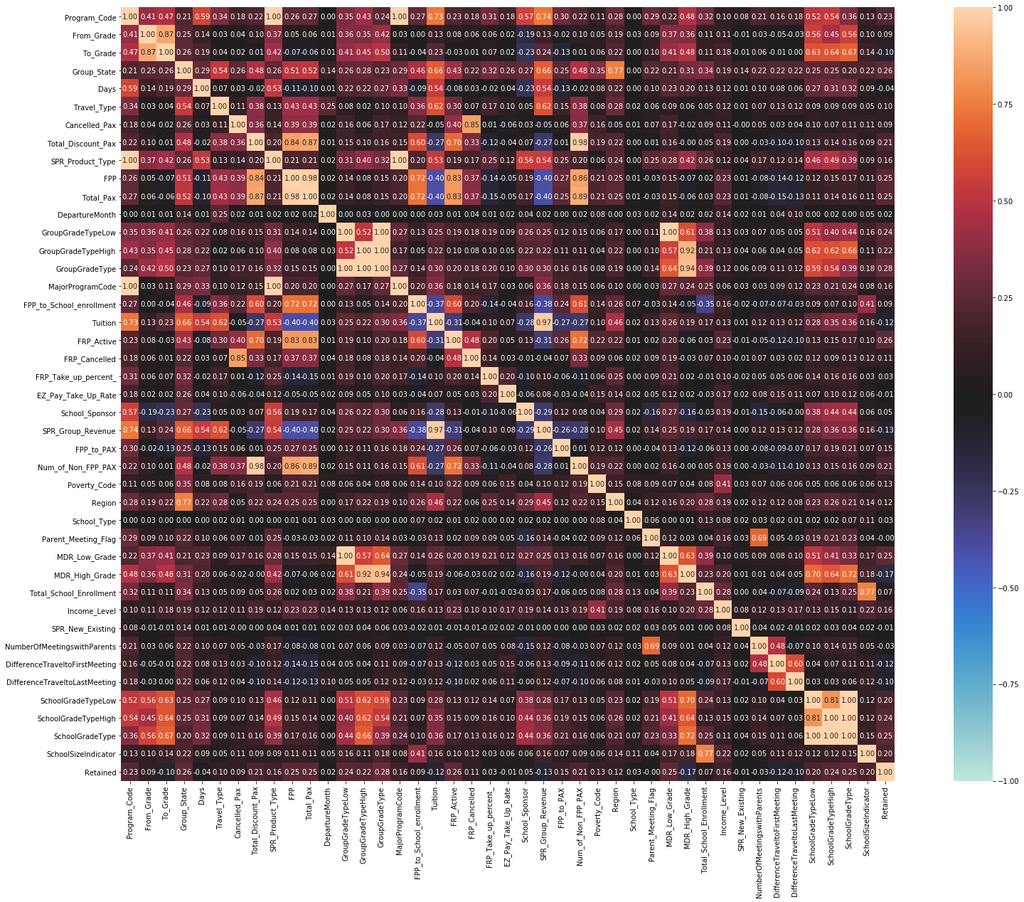

[output not shown]

[output cut: 352 more lines]

[output not shown]

```python
associations(clean_data1, figsize = (30,20))
```